# Nivel de bienestar personal de los alumnos de UTEC en épocas de pandemia (2020 a la actualidad)

#### IMC

**Distribución normal**

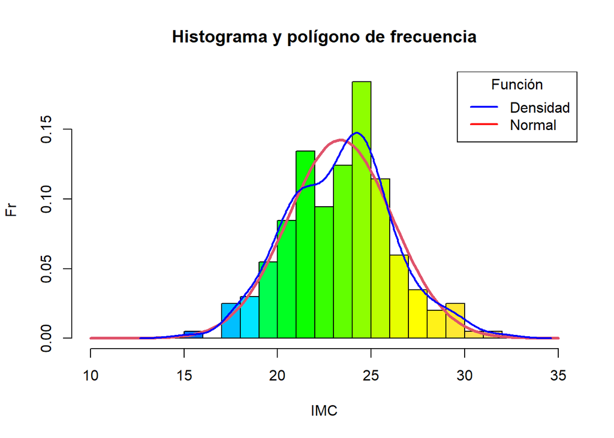

#### Promedio de notas

**Distribución normal**

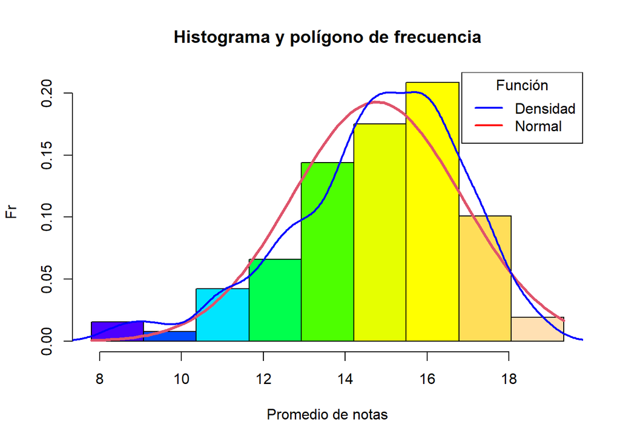

## Pruebas de hipótesis

### IMC

**Hipótesis 1:** El rango de un IMC normal es entre 18.5 y 25, entonces ¿se puede concluir que el promedio de IMC de los estudiantes de UTEC es de 21.75?

*H0: media del IMC es igual a 21.75*

*H1: media del IMC es diferente a 21.75*

```r
hipMedia(DF2$IMC,0.05,"bilateral",21.75)
```

```
## [1] "t1:  -1.97189622363391"
## [1] "t2:  1.97189622363391"
## [1] "tc:  8.12807672888875"
## [1] "H0 se rechaza"
```

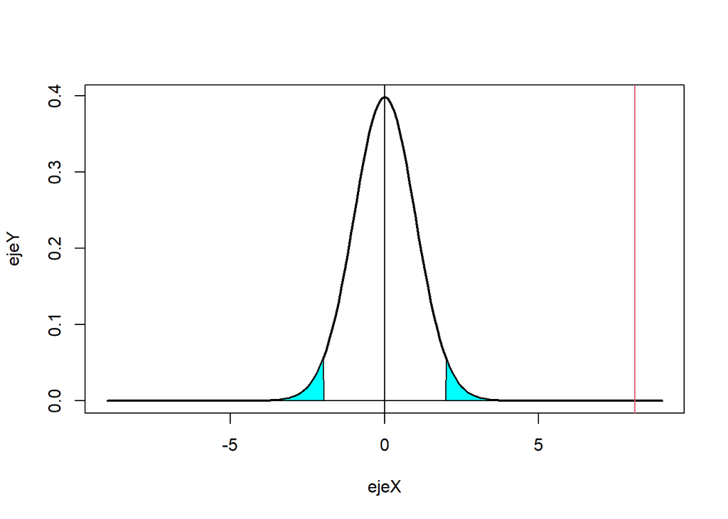

**Hipótesis 1: H0 se rechaza.** Por lo tanto, la media del IMC es diferente a 21.75

.

**Hipótesis 2:** La media del IMC está en el rango normal entre 18.5 y 25.

*H0_1: media de IMC menor o igual a 25*

*H1_1: media de IMC mayor a 25*

```r
hipMedia(DF2$IMC,0.05,"unilateral derecha",25)
```

```
## [1] "t:  1.65250810091088"
## [1] "tc:  -8.33659007723691"
## [1] "H0 se acepta"
```

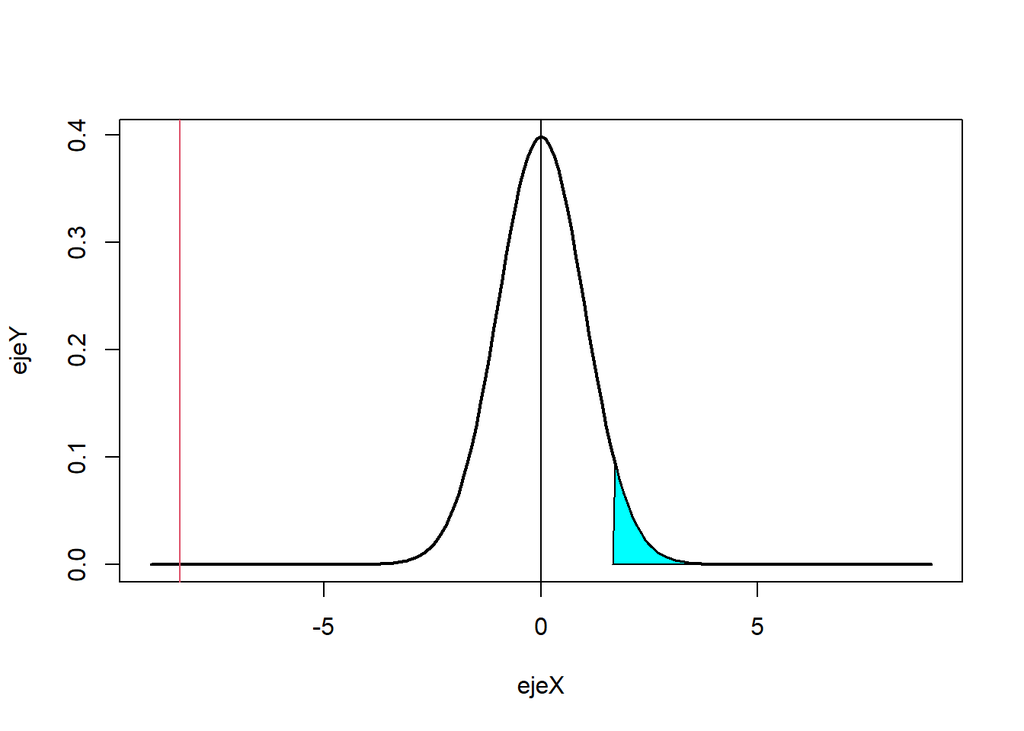

**No se rechaza la hipótesis nula** debido a que al decir que es menor o igual a 25 el promedio de IMC, su media real es de 23.35 por lo que se encuentra en el rango, es una decisión correcta.

*H0_2: media de IMC mayor o igual a 18.5*

*H1_2: media de IMC menor a 18.5*

```r
hipMedia(DF2$IMC,0.05,"unilateral izquierda",18.5)
```

```
## [1] "t:  -1.65250810091088"
## [1] "tc:  24.5927435350144"
## [1] "H0 se acepta"
```

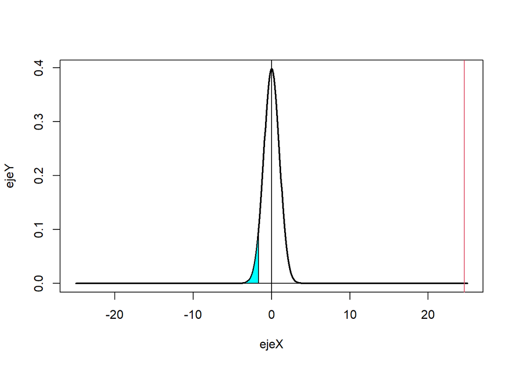

**No se rechaza la hipótesis nula** debido a que al decir que es mayor o igual a 18.5 el promedio de IMC, su media real es de 23.35 por lo que se encuentra en el rango, es una decisión correcta.

En síntesis, **H0_1 y H0_2 no son rechazadas**, entonces la media del IMC sí está entre 18.5 y 25

.

### Promedio de notas

**Hipótesis 3:** El promedio de notas de los estudiantes es mayor o igual a 15

*H0: media de Notas es mayor o igual a 15*

*H1: media de Notas es menor a 15*

```r
hipMedia(DF2$PromedioAnterior,0.05,"unilateral izquierda",15)
```

```
## [1] "t:  -1.65250810091088"
## [1] "tc:  -1.59234810123197"
## [1] "H0 se acepta"
```

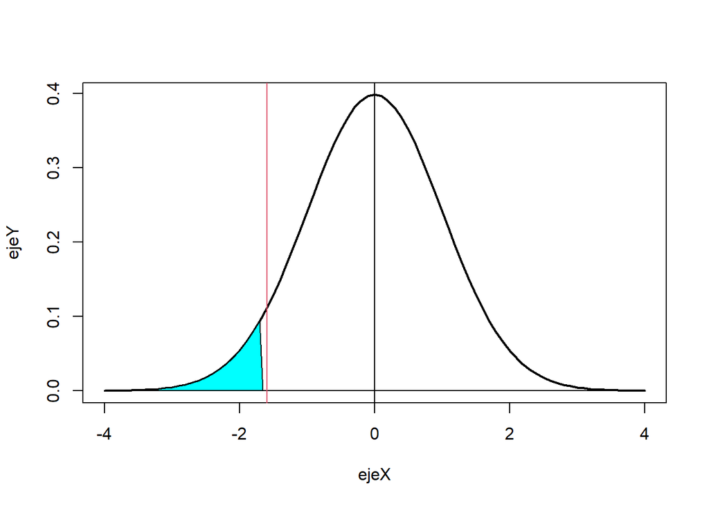

.

**Hipótesis 4:** la varianza de notas es mayor o igual al 50% de la media de notas

*H0: la varianza de Notas es mayor o igual al 50% de la media de notas*

*H1: la varianza de Notas es menor al 50% de la media de notas*

```r
hipVarianza(DF2$PromedioAnterior,0.05,"unilateral izquierda",0.5*mean(DF2$PromedioAnterior))
```

```
## [1] "X:  168.278554436628"
## [1] "Xc:  345.999535572939"
## [1] "H0 se acepta"
```

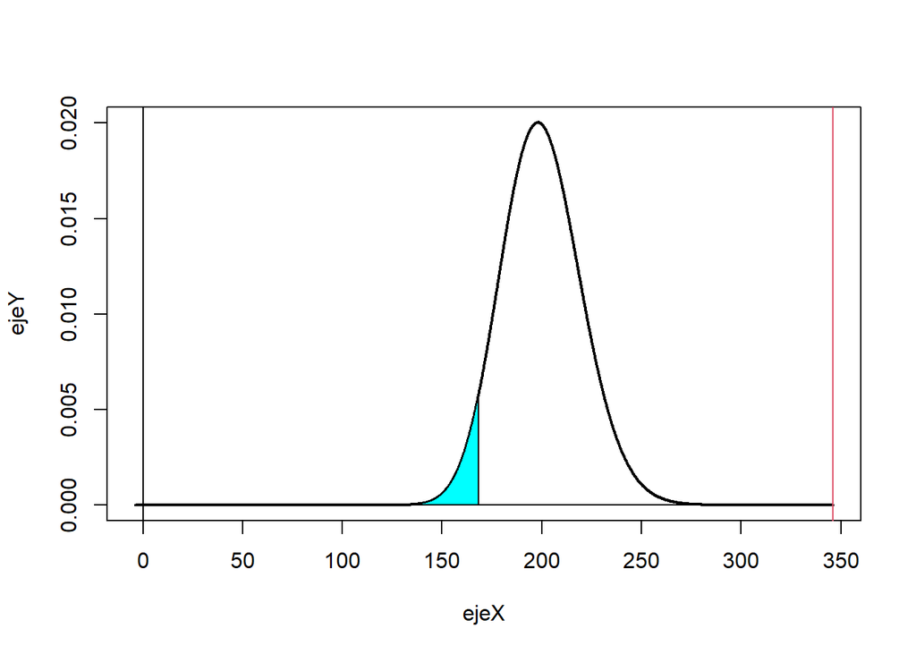

**Hipótesis 4: H0 no se rechaza.** Entonces la varianza de Notas es mayor o igual al 50% de la media de notas. Se ve que los estudiantes tienen calificaciones regulares y rango medio.

.

### Nivel de alimentación balanceada

**Hipótesis 5:** más del 50% de estudiantes considera que su alimentación es balanceada considerablemente (nivel 3)

*H0: la proporción de la alimentación balanceada de nivel 3 es mayor o igual al 50%*

*H1: la proporción de alimentación balanceada de nivel 3 menor al 50%*

```r
hipProporcion(DF2$AlimentacionBalance,0.05,"unilateral izquierda",0.5,3)
```

```
## [1] "Z:  -1.64485362695147"
## [1] "Zc:  -1.0580184237879"
## [1] "H0 se acepta"
```

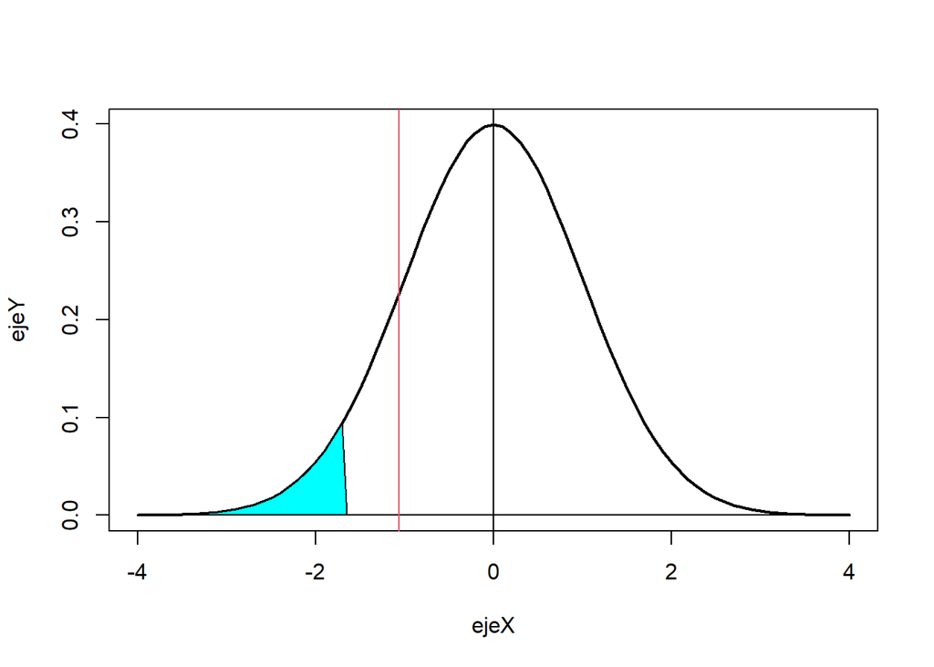

```r
#DF2$AlimentacionBalance[1]
```

**No se rechaza la hipótesis nula** debido a que la proporción de la alimentación es mayor o igual al 50% de las personas que tienen una alimentación balanceada de nivel 3 es mayor o igual al 50%, por lo que se tomó una decisión correcta. Por lo que se ve una vida saludable en la mayoría de estudiantes.

.

### Satisfación con las clases en linea

**Hipótesis 6:** la mayoría de estudiantes (más del 50 %) cree que las clases en línea no han sido ni muy productivas, ni muy perjudiciales.

*H0: la proporción de la satisfacción con las clases en línea de nivel 3 es mayor o igual al 50%*

*H1: la proporción de la satisfacción con las clases en línea de nivel 3 es menor al 50%*

```r
hipProporcion(DF2$SatisfaccionClases,0.05,"unilateral izquierda",0.5,3)
```

```
## [1] "Z:  -1.64485362695147"
## [1] "Zc:  -1.7633640396465"
## [1] "H0 se rechaza"
```

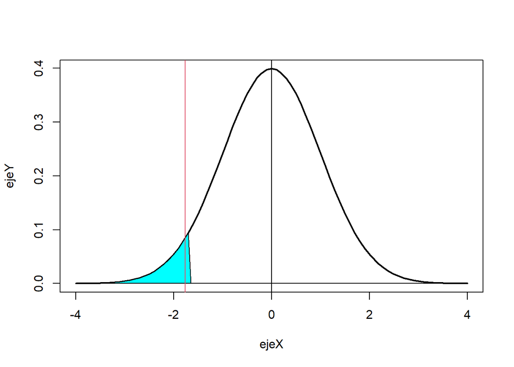

**Se rechaza la hipótesis nula**, entonces de la satisfacción con las clases en línea de nivel 3 es menor al 50%, se evalúa que se tomó una decisión correcta en la toma de niveles, se ve que los estudiantes se encuentran cómodos con las clases en línea.

## Patrones entre variables, regresión lineal y predicciones

### Variables de Salud

$BienestarSalud=IMC+HorasSueño+HorasActividadFísica+AlimentaciónBalanceada-PoseeEnfermedad$

**IMC — suma**

IMC el rango normal es ente 18.5 y 25, por tanto el valor óptimo del IMC es 21.75

*IMC fuera del rango mencionado no es lo óptimo*

**Horas de sueño — suma**

Según la Fundación Nacional del Sueño, afirma que lo recomendable es dormir de 7 a 9 horas. Por lo tanto, tomamos como 8 horas como la cantidad optima de sueño

*Horas fuera del rango mencionado no es lo óptimo*

**Horas de actividad física — suma**

Según la OMS lo recomendable es realizar al menos 2.5 horas de actividad física a la semana.

*un número inferior al mencionado no es óptimo*

*un número mayor al mencionado, es indiferente*

**Alimentación balanceada — suma**

**Poseer alguna enfermedad — resta**

Si posee alguna enfermedad toma el valor de 1

Si NO posee alguna enfermedad toma el valor de 0

| id | IMC | HorasZZZ | HorasFisica | AlimentacionBalance | Enfermedades | bienestar_Salud | colorVariable |
| --- | --- | --- | --- | --- | --- | --- | --- |
| 1 | 18.75000 | 6 | 2.250000 | 3 | 0 | 27.75000 | blueviolet |
| 2 | 18.58651 | 6 | 3.222222 | 4 | 0 | 29.55873 | blueviolet |
| 3 | 20.35950 | 4 | 2.250000 | 4 | 1 | 28.10950 | blueviolet |
| 4 | 19.84127 | 4 | 2.250000 | 4 | 0 | 28.59127 | blueviolet |
| 5 | 21.60494 | 6 | 2.250000 | 3 | 0 | 30.60494 | blueviolet |
| 6 | 19.19538 | 8 | 3.083333 | 3 | 0 | 30.27872 | blueviolet |
| 7 | 20.11131 | 7 | 3.000000 | 2 | 0 | 29.48631 | blueviolet |
| 8 | 19.53125 | 7 | 2.666667 | 4 | 0 | 30.57292 | blueviolet |
| 9 | 18.87704 | 7 | 3.142857 | 3 | 0 | 29.39490 | blueviolet |
| 10 | 19.94444 | 5 | 3.222222 | 3 | 0 | 29.29167 | blueviolet |

[output cut: 191 more lines]

#### IMC VS Bienestar en salud

#### (Aparenta tener una relación lineal cuadrática negativa)

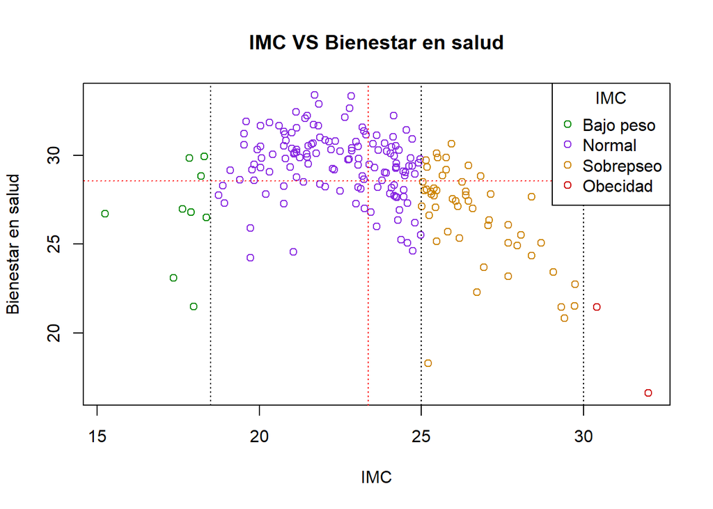

```r
plot(DF2$IMC,variablesSalud$bienestar_Salud,xlab="IMC",ylab = "Bienestar en salud",main = "IMC VS Bienestar en salud", col=variablesSalud$colorVariable)
abline(v=18.5, lty=3,col="black")
abline(v=25, lty=3,col="black")
abline(v=30, lty=3,col="black")
abline(h=35, lty=3,col="red")
abline(v=mean(DF2$IMC), lty=3,col="red")
abline(h=mean(variablesSalud$bienestar_Salud), lty=3,col="red")
legend(x="toprigh",legend = c("Bajo peso","Normal","Sobrepseo","Obecidad"),title = "IMC",pch = 1,col=c("green4","blueviolet","orange3","red3"))
```

Según la gráfica de correlación, notamos que la mayor concentración de datos está en las personas que tienen un IMC normal. Además, el comportamiento en la dispersión de los datos es de una parábola invertida, por lo que sugiere que mientras los datos de IMC se alejan del rango normal de 18.5 - 25, tienden a disminuir su bienestar de salud.

Además calculamos que el puntaje para el bienestar de salud óptimo (no necesariamente máximo) es de 35 puntos.

### Variables Académicas

$BienertarAcadémico=PromedioNotas+SatisfacciónNotas+SatisfacciónClasesVirtuales$ $+SatisfacciónCarrera+HorasEstudio+HorasDistracción-CursosDesaprobados-Cursos3raVez$

**Promedio de notas — suma**

**Satisfacción con notas — suma**

**Satisfacción con las clases virtuales — suma**

**Satisfacción con la carrera — suma**

**Horas al día de estudio — suma**

A pesar que la cantidad de horas que una persona estudia no determina mucho, según varias investigaciones, las horas recomendadas para que un alumno estudie ronda entre las 4 a 6 horas. *Por lo tanto, tomamos como 5 horas como la cantidad óptima de estudio*

*horas fuera del rango mencionado no es lo óptimo*

**Horas al día de distracción — suma**

Siempre es recomendable que la cantidad de horas de estudio sean similares a las que decida para distraerse.

*Por tanto, también tomamos como 5 horas como la cantidad óptima para distraerse*

*un número inferior al mencionado no es óptimo*

*un número mayor al mencionado, es indiferente*

**Cursos desaprobados — Resta**

**Cursos llevados por tercera vez — Resta**

| id | PromedioAnterior | SatisfaccionResultados | SatisfaccionClases | SatisfaccionCarrera | HorasEstudio | HorasDistraccion | CursosDesaprobados | CursosMatric3era | bienestar_Academico | colorVariable |
| --- | --- | --- | --- | --- | --- | --- | --- | --- | --- | --- |
| 1 | 17.27 | 3 | 3 | 3 | 0 | 3.500000 | 0 | 0 | 29.770000 | orange3 |
| 2 | 14.00 | 3 | 3 | 5 | 0 | 4.333333 | 0 | 0 | 29.333333 | blueviolet |
| 3 | 14.56 | 1 | 3 | 3 | 5 | 5.545455 | 0 | 0 | 32.105455 | blueviolet |
| 4 | 13.00 | 4 | 5 | 5 | -2 | 5.000000 | 1 | 0 | 29.000000 | blueviolet |
| 5 | 15.32 | 3 | 3 | 4 | 4 | 4.333333 | 0 | 0 | 33.653333 | orange3 |
| 6 | 12.00 | 1 | 2 | 4 | 2 | 4.333333 | 3 | 4 | 18.333333 | green4 |
| 7 | 13.00 | 2 | 4 | 4 | 3 | 4.750000 | 2 | 0 | 28.750000 | blueviolet |
| 8 | 17.01 | 4 | 4 | 5 | 2 | 3.500000 | 0 | 0 | 35.510000 | orange3 |
| 9 | 11.00 | 2 | 3 | 5 | 2 | 3.500000 | 3 | 1 | 22.500000 | green4 |
| 10 | 15.59 | 3 | 4 | 4 | 2 | 4.333333 | 0 | 0 | 32.923333 | orange3 |

[output cut: 191 more lines]

#### Bienestar académico VS Notas

#### (Aparenta tener una relación lineal positiva)

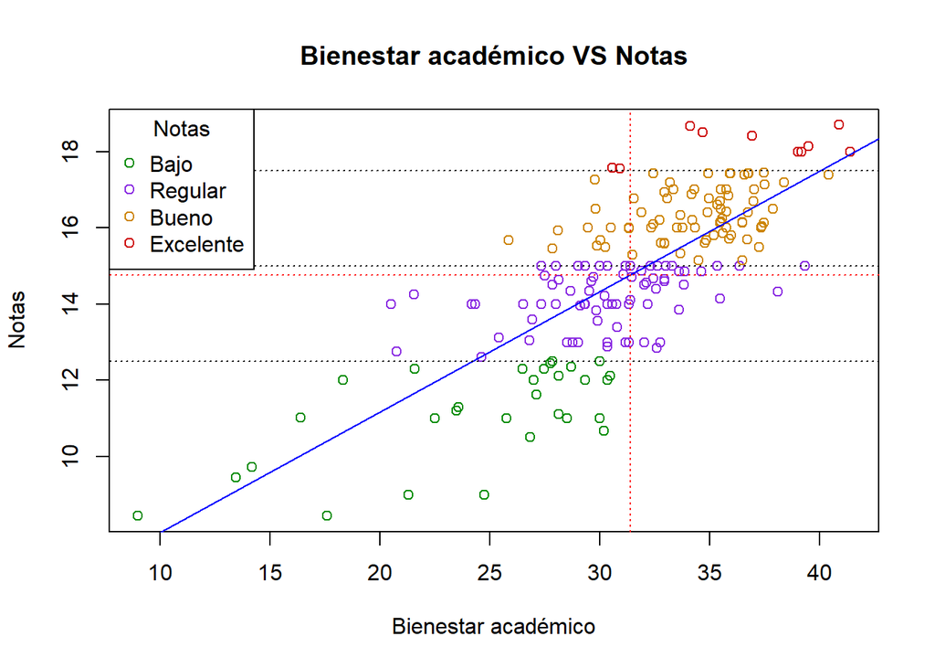

```r
plot(variablesAcademicas$PromedioAnterior~variablesAcademicas$bienestar_Academico,xlab="Bienestar académico",ylab = "Notas",main = "Bienestar académico VS Notas",col=variablesAcademicas$colorVariable);
abline(lm(variablesAcademicas$PromedioAnterior~variablesAcademicas$bienestar_Academico), lty=1,col="blue")
abline(h=12.5, lty=3,col="black")
abline(h=15, lty=3,col="black")
abline(h=17.5, lty=3,col="black")
abline(v=45, lty=3,col="red")
abline(v=mean(variablesAcademicas$bienestar_Academico), lty=3,col="red")
abline(h=mean(variablesAcademicas$PromedioAnterior), lty=3,col="red")
legend(x="topleft",legend = c("Bajo","Regular","Bueno","Excelente"),title = "Notas",pch = 1,col=c("green4","blueviolet","orange3","red3"))
```

Según la gráfica de correlación, podemos ver que los datos presentan un ajuste lineal creciente. Esto quiere decir que, mientras el bienestar académico de un estudiante sea muy bajo, es muy probable que sus notas sean muy bajas, y, sin embargo, mientras su bienestar es mucho mejor, tiene más posibilidades de tener mayor al promedio.

### Relación Lineal

```r
cor.test(variablesAcademicas$bienestar_Academico,variablesAcademicas$PromedioAnterior)
```

```
##
##  Pearson's product-moment correlation
##
## data:  variablesAcademicas$bienestar_Academico and variablesAcademicas$PromedioAnterior
## t = 17.062, df = 199, p-value < 0.00000000000000022
## alternative hypothesis: true correlation is not equal to 0
## 95 percent confidence interval:
##  0.7077870 0.8214671
## sample estimates:
##       cor
## 0.7706896
```

Presenta una correlación lineal fuerte, lo que indica que ambas variables tienen relación lineal y positiva

```r
modelo2<-lm(formula=variablesAcademicas$PromedioAnterior~variablesAcademicas$bienestar_Academico)
summary(modelo2)
```

```
##
## Call:
## lm(formula = variablesAcademicas$PromedioAnterior ~ variablesAcademicas$bienestar_Academico)
##
## Residuals:
##     Min      1Q  Median      3Q     Max
## -3.7095 -0.7548  0.0644  0.8787  3.0570
##
## Coefficients:
##                                         Estimate Std. Error t value
## (Intercept)                              4.82963    0.58988   8.187
## variablesAcademicas$bienestar_Academico  0.31676    0.01857  17.062
##                                                     Pr(>|t|)
## (Intercept)                               0.0000000000000316 ***
## variablesAcademicas$bienestar_Academico < 0.0000000000000002 ***
## ---
## Signif. codes:  0 '***' 0.001 '**' 0.01 '*' 0.05 '.' 0.1 ' ' 1
##
## Residual standard error: 1.32 on 199 degrees of freedom
## Multiple R-squared:  0.594,  Adjusted R-squared:  0.5919
## F-statistic: 291.1 on 1 and 199 DF,  p-value: < 0.00000000000000022
```

El R^2 nos indica que el 59.19% de la variabilidad de las notas es explicada a través del bienestar académico.

**Teniendo en cuenta que el nivel de significancia es de un 5%**

El P-value asociado a la regresión lineal (p-value: < 2.2*10^-16) nos responde a la siguiente hipótesis:

*H0: Todos los coeficientes son diferentes de cero*

*H1: Al menos algún coeficiente son diferente de cero*

El p-value asociado a cada uno de los coeficientes (Pr) responde a la hipótesis:

*H0: El coeficiente correspondiente es igual a cero*

*H1: El coeficiente correspondiente no es igual a cero*

*Por lo cual rechazamos la hipótesis nula para el P-value asociado a los coeficientes*

```r
a1<-modelo2$coefficients
a1
```

```
##                             (Intercept) variablesAcademicas$bienestar_Academico
##                               4.8296278                               0.3167604
```

#### Predicciones

```
## [1] "Entonces se estima que para que un alumno tenga una nota de 20, tendría que obtener un puntaje superior a los:  47.89  puntos en bienestar académico. "
```

```
## [1] "En cambio, para un alumno que este en riesgo académico (nota de 10), tiene un bienestar académico de:  16.32  puntos "
```

Además, se calcula que el puntaje para el bienestar académico óptimo (no necesariamente máximo) es de 45 puntos.

### Todas las variables

$fBienestarTotal=BienestarSalud+BienestarAcadémico-EstudiaTrabaja+IngresoDinero+RecursosTecnológicos$

Por lo tanto se estima que el puntaje para el bienestar total óptimo (no necesariamente máximo) es de 95 puntos.

**Bienestar académico — suma**

**Bienestar en Salud — suma**

**Estudia o trabaja — resta**

*En caso que estudie o trabaje, la variable toma un valor de 1*

*En caso que solo estudie, la variable toma un valor de 0*

**Ingreso promedio de dinero al hogar — suma**

Según el INEI, el ingreso promedio mensual proveniente del trabajo en Lima Metropolitana se situó en 1790,5 soles. Entonces:

*un valor inferior al mencionado no es del todo óptimo*

*un número mayor al mencionado, es indiferente*

**Recursos tecnológicos que dispone — suma**

Se determinará con la cantidad y de importancia de los recursos que dispone el encuestado. Ejemplo:

Teléfono = 1

Internet, Teléfono = 2

Laptop o PC = 3

Laptop o PC, Teléfono = 4

Internet, Laptop o PC = 4

Laptop o PC, Teléfono, Impresora = 5

Internet, Laptop o PC, Impresora = 5

Internet, Laptop o PC, Teléfono = 5

Internet, Laptop o PC, Teléfono, Impresora = 7

Internet, Laptop o PC, Impresora, Tablet o Ipad = 8

Internet, Laptop o PC, Teléfono, Tablet o Ipad = 8

Internet, Laptop o PC, Tablet o Ipad = 8

Internet, Laptop o PC, Teléfono, Impresora, Tablet o Ipad = 10

| id | IMC | PromedioAnterior | bienestar_Salud | bienestar_Academico | EstudiarTrabajar | IngresoPromedioFamiliar | RecursosTecnologicos | bienestar_Total | colorVariable |
| --- | --- | --- | --- | --- | --- | --- | --- | --- | --- |
| 1 | 18.75000 | 17.27 | 27.75000 | 29.770000 | 0 | 4.702344 | 6 | 66.02000 | Blue |
| 2 | 24.91349 | 14.00 | 29.55873 | 29.333333 | 0 | 6.604750 | 6 | 69.39206 | Blue |
| 3 | 23.14050 | 14.56 | 28.10950 | 32.105455 | 0 | 3.023750 | 5 | 66.96496 | Blue |
| 4 | 19.84127 | 13.00 | 28.59127 | 29.000000 | 0 | 2.788158 | 5 | 63.34127 | Blue |
| 5 | 21.60494 | 15.32 | 30.60494 | 33.653333 | 0 | 3.769792 | 6 | 71.75827 | Blue |
| 6 | 24.30462 | 12.00 | 30.27872 | 18.333333 | 1 | 3.023750 | 5 | 53.11205 | Blue |
| 7 | 23.38869 | 13.00 | 29.48631 | 28.750000 | 0 | 1.904687 | 5 | 62.98631 | Blue |
| 8 | 19.53125 | 17.01 | 30.57292 | 35.510000 | 0 | 3.023750 | 6 | 73.58292 | Blue |
| 9 | 24.62296 | 11.00 | 29.39490 | 22.500000 | 0 | 6.007917 | 5 | 61.64490 | Blue |
| 10 | 23.55556 | 15.59 | 29.29167 | 32.923333 | 1 | 6.221071 | 6 | 70.46500 | violetred |

[output cut: 191 more lines]

### IMC VS Bienestar Total

#### (NO presenta ninguna relación)

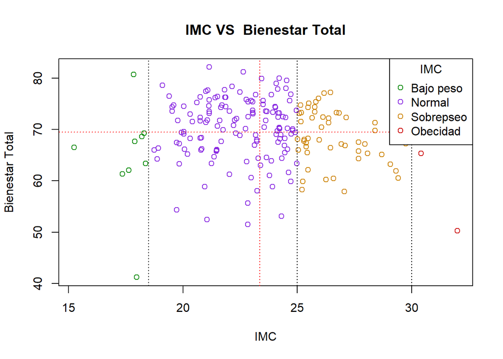

```r
plot(DF2$IMC,VariablesTotales$bienestar_Total,xlab="IMC",ylab = "Bienestar Total",main = "IMC VS  Bienestar Total",col=variablesSalud$colorVariable)
abline(v=18.5, lty=3,col="black")
abline(v=25, lty=3,col="black")
abline(v=30, lty=3,col="black")
abline(h=94.25, lty=3,col="red")
abline(h=mean(VariablesTotales$bienestar_Total), lty=3,col="red")
abline(v=mean(VariablesTotales$IMC), lty=3,col="red")
legend(x="toprigh",legend = c("Bajo peso","Normal","Sobrepseo","Obecidad"),title = "IMC",pch = 1,col=c("green4","blueviolet","orange3","red3"))
```

Según la gráfica, se puede observar que los datos están muy dispersos por lo que no pueden tener un ajuste óptimo para determinar si hay una relación entre la condición física de una persona y su bienestar total. Puede pasar que muchas personas se sientan bien en la parte académica mientras que en el ámbito de salud sea todo lo contrario y todo esto no depende de su condición física. Es por eso que no se puede determinar una relación exacta entre estas variables.

### Bienestar Total VS Notas

#### (Aparenta tener una relación lineal positiva)

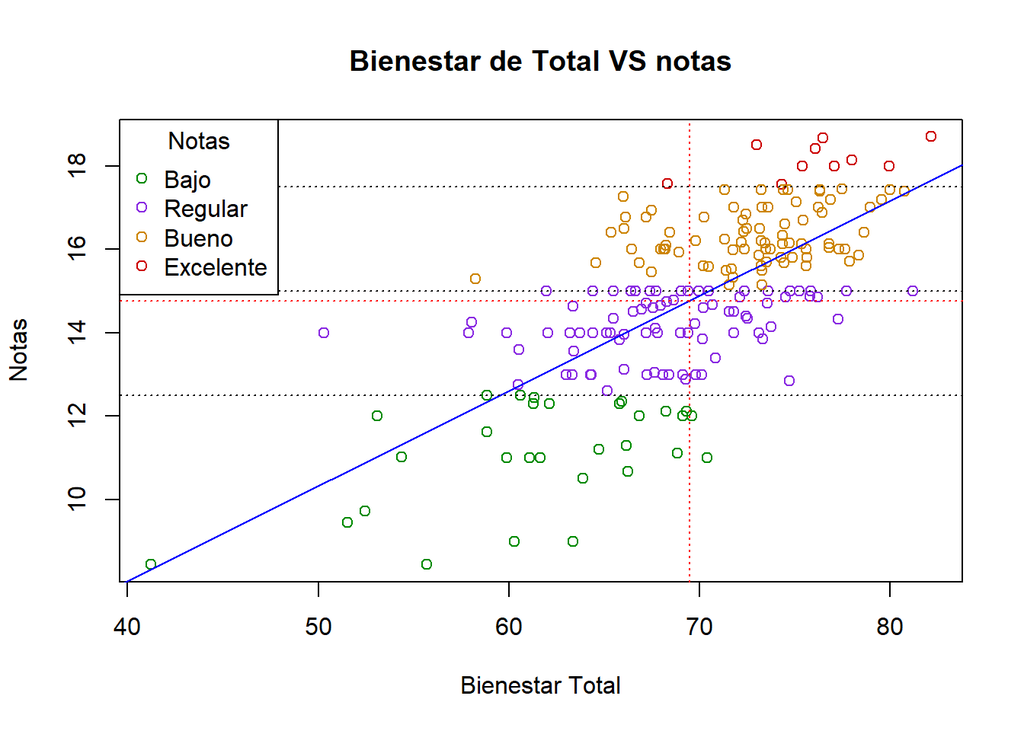

```r
plot(DF2$PromedioAnterior~VariablesTotales$bienestar_Total,xlab="Bienestar Total",ylab = "Notas",main = "Bienestar de Total VS notas",col=variablesAcademicas$colorVariable);
abline(lm(DF2$PromedioAnterior~VariablesTotales$bienestar_Total), lty=1,col="blue")
abline(h=12.5, lty=3,col="black")
abline(h=15, lty=3,col="black")
abline(h=17.5, lty=3,col="black")
abline(v=94.25, lty=3,col="red")
abline(v=mean(VariablesTotales$bienestar_Total), lty=3,col="red")
abline(h=mean(VariablesTotales$PromedioAnterior), lty=3,col="red")
legend(x="topleft",legend = c("Bajo","Regular","Bueno","Excelente"),title = "Notas",pch = 1,col=c("green4","blueviolet","orange3","red3"))
```

Según la gráfica de correlación, se puede ver que los datos presentan un ajuste lineal creciente, esto es debido a que mientras más alta sea el bienestar total de un estudiante, es más probable que tenga mayores calificaciones. Además, podemos ver que muchas personas al tener una nota promedio tienen un bienestar promedio, lo que también compensa a los demás bienestares (de salud y académico)

### RElación Lineal

```r
cor.test(VariablesTotales$bienestar_Total,DF2$PromedioAnterior)
```

```
##
##  Pearson's product-moment correlation
##
## data:  VariablesTotales$bienestar_Total and DF2$PromedioAnterior
## t = 13.687, df = 199, p-value < 0.00000000000000022
## alternative hypothesis: true correlation is not equal to 0
## 95 percent confidence interval:
##  0.6174449 0.7613599
## sample estimates:
##       cor
## 0.6963369
```

Presenta una correlación lineal no tal fuerte, lo que indica que ambas variables tiene relación lineal moderada y positiva

```r
modelo3<-lm(formula=DF2$PromedioAnterior~VariablesTotales$bienestar_Total)
summary(modelo3)
```

```
##
## Call:
## lm(formula = DF2$PromedioAnterior ~ VariablesTotales$bienestar_Total)
##
## Residuals:
##     Min      1Q  Median      3Q     Max
## -4.3800 -0.9505  0.1208  1.0008  3.6079
##
## Coefficients:
##                                  Estimate Std. Error t value
## (Intercept)                      -1.08568    1.16307  -0.933
## VariablesTotales$bienestar_Total  0.22822    0.01668  13.687
##                                             Pr(>|t|)
## (Intercept)                                    0.352
## VariablesTotales$bienestar_Total <0.0000000000000002 ***
## ---
## Signif. codes:  0 '***' 0.001 '**' 0.01 '*' 0.05 '.' 0.1 ' ' 1
##
## Residual standard error: 1.486 on 199 degrees of freedom
## Multiple R-squared:  0.4849, Adjusted R-squared:  0.4823
## F-statistic: 187.3 on 1 and 199 DF,  p-value: < 0.00000000000000022
```

**Teniendo en cuenta que el nivel de significancia es de un 5%**

El P-value asociado a la regresión lineal (p-value: < 2.2*10^-16) nos responde a la siguiente hipótesis:

*H0: Todos los coeficientes son diferentes de cero*

*H1: Al menos algún coeficiente son diferente de cero*

El p-value asociado al coeficiente de la intercepción (Pr<0.352) responde a la hipótesis:

*H0: El coeficiente es igual a cero*

*H1: El coeficiente no es igual a cero*

*Por lo cual no rechazamos la hipótesis nula para el P-value al coeficiente de la intercepción, por lo que podemos decir que el intecepto se puede considerar 0*

El p-value asociado al coeficiente de la pendiente (Pr< 2.2*10^-16) responde a la hipótesis:

*H0: El coeficiente es igual a cero*

*H1: El coeficiente no es igual a cero*

*Por lo cual rechazamos la hipótesis nula para el P-value al coeficiente de la pendiente*

```r
a3<-modelo3$coefficients
a3
```

```
##                      (Intercept) VariablesTotales$bienestar_Total
##                       -1.0856849                        0.2282241
```

#### Predicciones

[output not shown]

[output not shown]

### Bienestar Académico VS Bienestar Total

#### (Aparenta tener una relación lineal positiva)

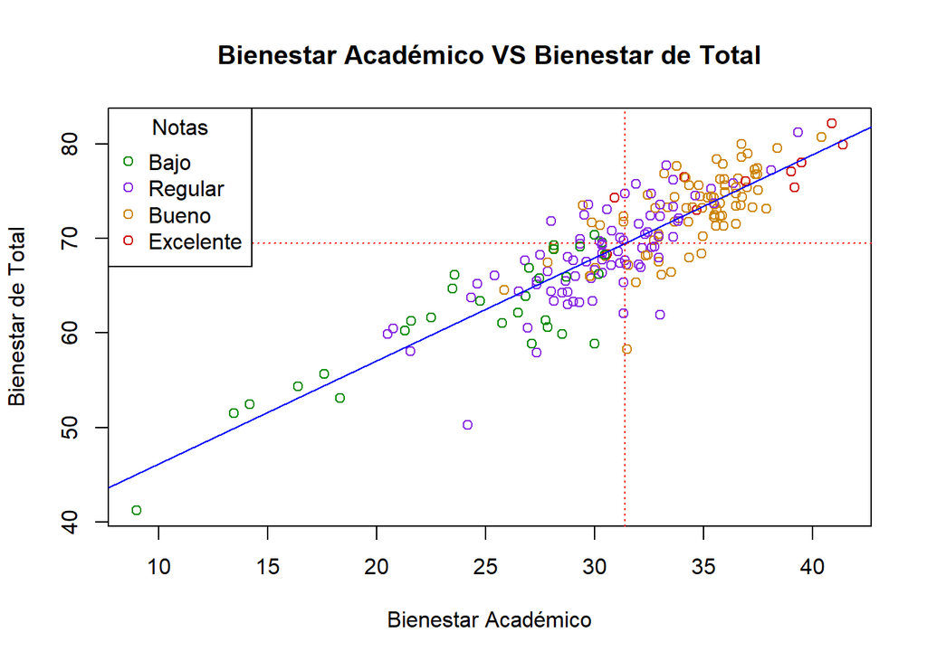

```r
plot(VariablesTotales$bienestar_Total~variablesAcademicas$bienestar_Academico,xlab="Bienestar Académico",ylab = "Bienestar de Total",main = "Bienestar Académico VS Bienestar de Total",col=variablesAcademicas$colorVariable)
abline(lm(VariablesTotales$bienestar_Total~variablesAcademicas$bienestar_Academico), lty=1,col="blue")
abline(h=94.25, lty=3,col="red")
abline(h=mean(VariablesTotales$bienestar_Total), lty=3,col="red")
abline(v=45, lty=3,col="red")
abline(v=mean(VariablesTotales$bienestar_Academico), lty=3,col="red")
legend(x="topleft",legend = c("Bajo","Regular","Bueno","Excelente"),title = "Notas",pch = 1,col=c("green4","blueviolet","orange3","red3"))
```

Según la gráfica, los datos presentan una relación lineal creciente, lo que sugiere que, a mayor bienestar académico de un estudiante hay mucha posibilidad de que tenga un mayor bienestar total. Por lo cual, se puede notar que el bienestar académico es determinante en el bienestar del estudiante UTEC, y, por el contrario, el bienestar en la salud no presenta tanta relevancia en el bienestar total.

### Relación Lineal

```r
cor.test(variablesAcademicas$bienestar_Academico,VariablesTotales$bienestar_Total)
```

```
##
##  Pearson's product-moment correlation
##
## data:  variablesAcademicas$bienestar_Academico and VariablesTotales$bienestar_Total
## t = 24.812, df = 199, p-value < 0.00000000000000022
## alternative hypothesis: true correlation is not equal to 0
## 95 percent confidence interval:
##  0.8308873 0.8994958
## sample estimates:
##       cor
## 0.8693187
```

Presenta una correlación lineal es muy fuerte, lo que indica que ambas variables tiene relación lineal fuerte y positiva

```r
modelo4<-lm(formula=VariablesTotales$bienestar_Tota~variablesAcademicas$bienestar_Academico)
summary(modelo4)
```

```
##
## Call:
## lm(formula = VariablesTotales$bienestar_Tota ~ variablesAcademicas$bienestar_Academico)
##
## Residuals:
##      Min       1Q   Median       3Q      Max
## -11.3155  -1.8004   0.0814   2.0152   6.1575
##
## Coefficients:
##                                         Estimate Std. Error t value
## (Intercept)                             35.26172    1.39601   25.26
## variablesAcademicas$bienestar_Academico  1.09015    0.04394   24.81
##                                                    Pr(>|t|)
## (Intercept)                             <0.0000000000000002 ***
## variablesAcademicas$bienestar_Academico <0.0000000000000002 ***
## ---
## Signif. codes:  0 '***' 0.001 '**' 0.01 '*' 0.05 '.' 0.1 ' ' 1
##
## Residual standard error: 3.123 on 199 degrees of freedom
## Multiple R-squared:  0.7557, Adjusted R-squared:  0.7545
## F-statistic: 615.6 on 1 and 199 DF,  p-value: < 0.00000000000000022
```

**Teniendo en cuenta que el nivel de significancia es de un 5%**

El P-value asociado a la regresión lineal (p-value: < 2.2*10^-16) nos responde a la siguiente hipótesis:

*H1: Al menos algún coeficiente son diferente de cero*

El p-value asociado a cada uno de los coeficientes (Pr) responde a la hipótesis:

*H0: El coeficiente correspondiente es igual a cero*

*H1: El coeficiente correspondiente no es igual a cero*

*Por lo cual rechazamos la hipótesis nula para el P-value asociado a los coeficientes*

```r
a4<-modelo4$coefficients
a4
```

```
##                             (Intercept) variablesAcademicas$bienestar_Academico
##                               35.261717                                1.090155
```

#### Predicciones

```
## [1] "Comparado con las predicciones anteriores, se puede concluir que basta con un bienestar académico alrededor de los 40 puntos para tener un buen bienestar total y por lo tanto, puede ser beneficioso es sus notas."
```

```
## [1] "En cambio, si el estudiante tiene un bienestar académico menor que 25 puntos, se puede predecir que el estudiante tendrá un bajo bienestar total y por tanto puede ser contra producente en sus notas."
```

### Gráficos adicionales

#### Bienestar en salud

##### Descriptores numéricos

```r
descpNumericos(VariablesTotales$bienestar_Salud)
```

```
## [1] "Promedio:  28.55"
## [1] "Intervalo de confianza del promedio: [  28.17  :  28.93  ]"
## [1] "desviación estandar:  2.7"
## [1] "Intervalo de confianza de la desviación estandar: [  2.46  :  2.99  ]"
## [1] "Varianza:  7.29"
## [1] "Intervalo de confianza de la varianza: [  6.05  :  8.96  ]"
## [1] "Mediana:  29.1"
```

```
##    Min. 1st Qu.  Median    Mean 3rd Qu.    Max.
##   16.62   27.43   29.10   28.55   30.32   33.37
```

##### Gráfica de boxplot de Bienestar en salud

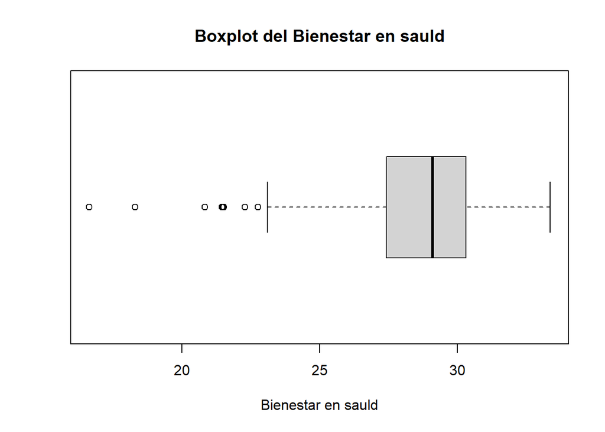

```r
boxplot(VariablesTotales$bienestar_Salud,horizontal=TRUE, xlab="Bienestar en sauld",main = "Boxplot del Bienestar en sauld")
```

[figure not shown]

```r
hist(VariablesTotales$bienestar_Academico,col=c(1:10), xlab = "Bienestar en sauld",main = "Histograma del Bienestar en sauld")
```

#### Bienestar académico

##### Descriptores numéricos

```r
descpNumericos(VariablesTotales$bienestar_Academico)
```

```
## [1] "Promedio:  31.37"
## [1] "Intervalo de confianza del promedio: [  30.67  :  32.07  ]"
## [1] "desviación estandar:  5.03"
## [1] "Intervalo de confianza de la desviación estandar: [  4.58  :  5.58  ]"
## [1] "Varianza:  25.3"
## [1] "Intervalo de confianza de la varianza: [  20.99  :  31.1  ]"
## [1] "Mediana:  31.9"
```

```
##    Min. 1st Qu.  Median    Mean 3rd Qu.    Max.
##   8.985  29.000  31.900  31.375  34.947  41.375
```

##### Gráfica de boxplot de Bienestar académico

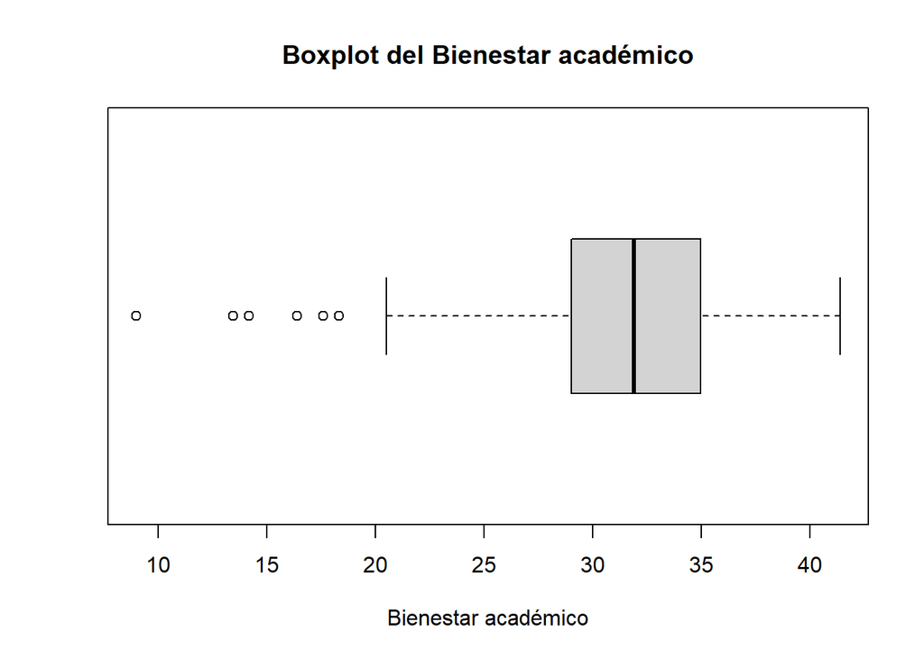

```r
boxplot(VariablesTotales$bienestar_Academico,horizontal=TRUE, xlab="Bienestar académico",main = "Boxplot del Bienestar académico")
```

##### Histograma de Bienestar académico

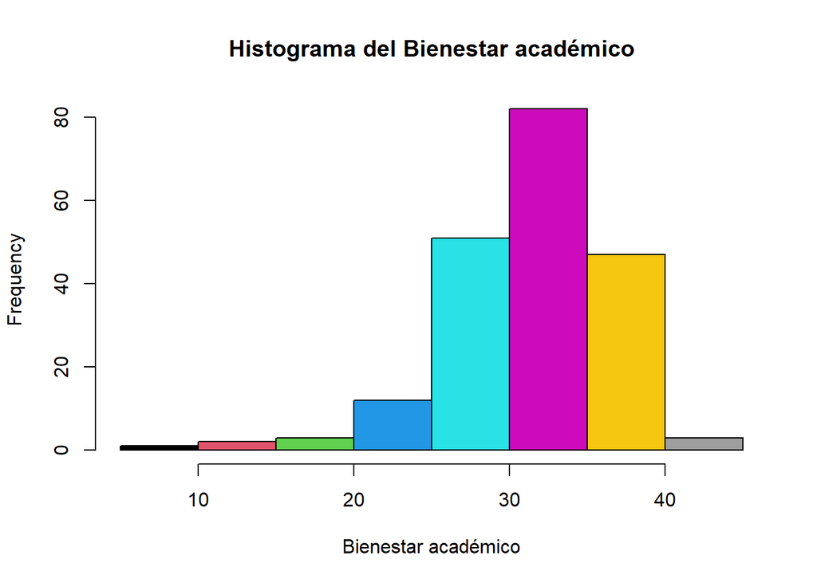

```r
hist(VariablesTotales$bienestar_Academico,col=c(1:10), xlab = "Bienestar académico",main = "Histograma del Bienestar académico")
```

#### Descripción de Bienestar total

##### Descriptores numéricos

```r
descpNumericos(VariablesTotales$bienestar_Total)
```

```
## [1] "Promedio:  69.47"
## [1] "Intervalo de confianza del promedio: [  68.59  :  70.35  ]"
## [1] "desviación estandar:  6.3"
## [1] "Intervalo de confianza de la desviación estandar: [  5.74  :  6.98  ]"
## [1] "Varianza:  39.69"
## [1] "Intervalo de confianza de la varianza: [  32.93  :  48.78  ]"
## [1] "Mediana:  69.95"
```

```
##    Min. 1st Qu.  Median    Mean 3rd Qu.    Max.
##   41.22   66.04   69.95   69.47   73.76   82.15
```

##### Gráfica de boxplot de Bienestar total

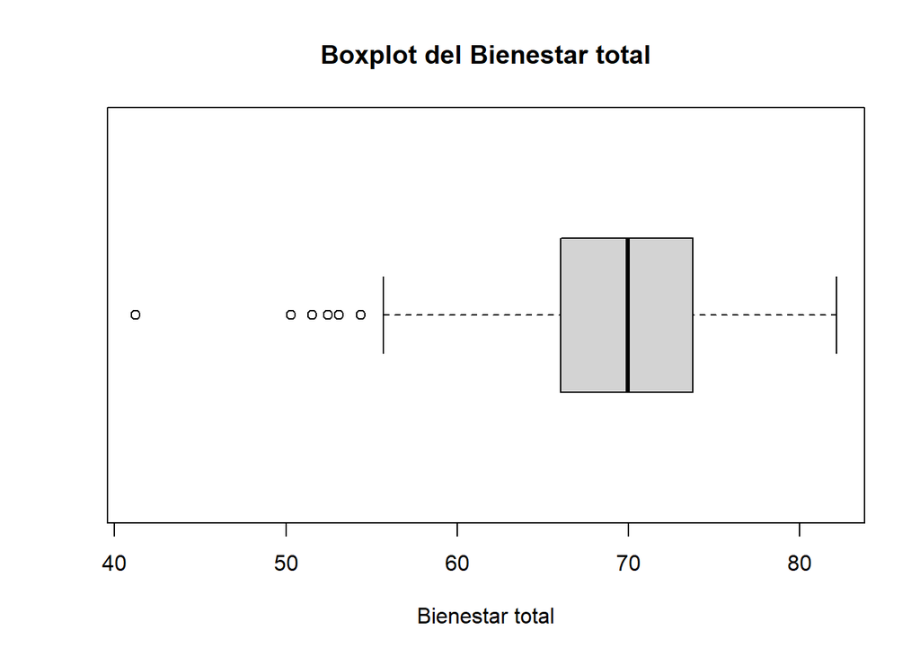

```r
boxplot(VariablesTotales$bienestar_Total,horizontal=TRUE, xlab="Bienestar total",main = "Boxplot del Bienestar total")
```

##### Histograma de Bienestar total

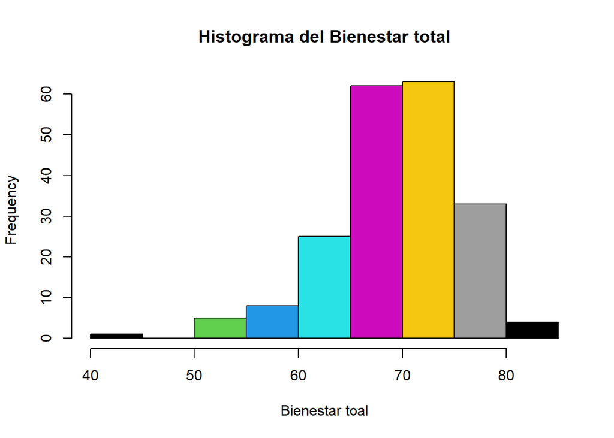

[output not shown]

[output cut: 191 more lines]

```r
hist(VariablesTotales$bienestar_Total,col=c(1:10), xlab = "Bienestar toal",main = "Histograma del Bienestar total")
```

#### Gráfico de mosaico: IMC VS Género

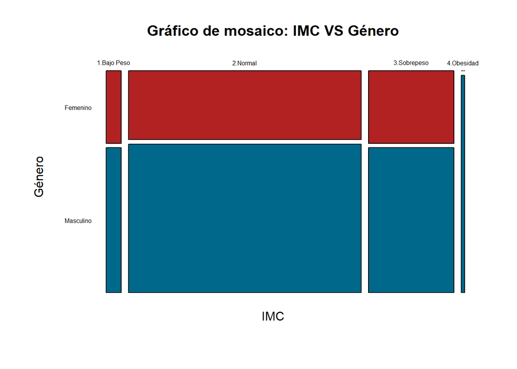

```r
mosaicplot(datosNuevos$rangoIMC~datosNuevos$Genero,col=c("firebrick","deepskyblue4"),
           main="Gráfico de mosaico: IMC VS Género",
           xlab="IMC",
           ylab="Género",
           cex.axis=0.5,
           las=1)
```

#### Gráfico de mosaico: Notas VS Género

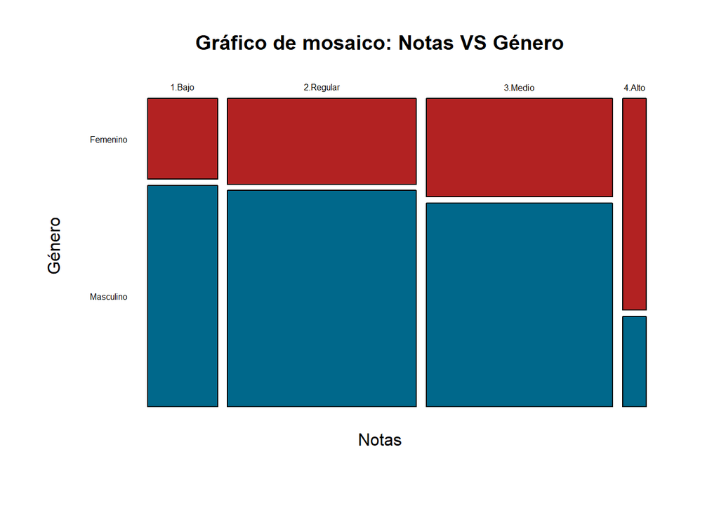

```r
mosaicplot(datosNuevos$rangoNotas~datosNuevos$Genero,col=c("firebrick","deepskyblue4"),
           main="Gráfico de mosaico: Notas VS Género",
           xlab="Notas",
           ylab="Género",
           cex.axis=0.5,
           las=1)
```

Podemos observar que la cantidad de estudiantes es de una misma proporción cuando tienen notas Regulares y Medias, se observa que los varones son los más frecuentes en sacar este tipo de notas. Sin embargo, las mujeres son más frecuentes en sacar notas altas que los varones, aunque la cantidad de alumnos para este rango sea muy poca. Para el caso de bajas notas los varones son más frecuentes en sacar baja nota.

#### Gráfico de mosaico: Bienestar en salud VS Género

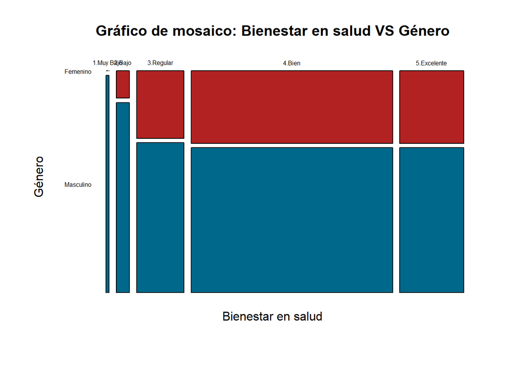

```r
mosaicplot(datosNuevos$rangoBS~datosNuevos$Genero,col=c("firebrick","deepskyblue4"),
           main="Gráfico de mosaico: Bienestar en salud VS Género",
           xlab="Bienestar en salud",
           ylab="Género",
           cex.axis=0.5,
           las=1)
```

Como caso general, hay una mayor cantidad de varones en los rangos de bienestar, a comparación de las mujeres. El bienestar que tiene la mayoría de los alumnos es de Bien, aquí podemos relacionar factores como la alimentación balanceada, sus actividades físicas, las horas de sueño, entre otros. Además, observamos que algunos almunos que se encuentran en un rango de bienestar excelente, donde también predominan los varones. Sin embargo, podemos ver que hay muy poco alumnado en el rango de un bienestar muy bajo, se infiere del gráfico de IMC como las personas con obesidad y algunas que se encuentran en bajo peso y sobrepeso.

#### Gráfico de mosaico: Bienestar académico vs Género

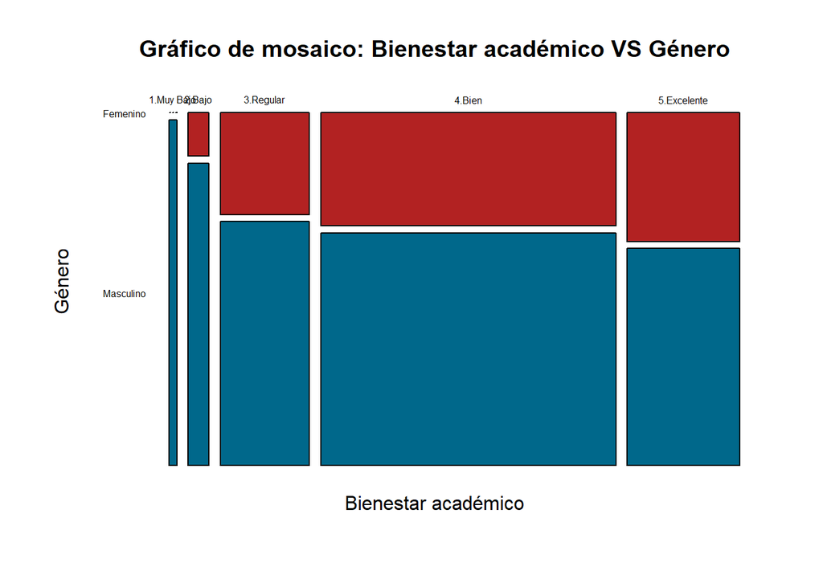

```r
mosaicplot(datosNuevos$rangoAc~datosNuevos$Genero,col=c("firebrick","deepskyblue4"),
           main="Gráfico de mosaico: Bienestar académico VS Género",
           xlab="Bienestar académico",
           ylab="Género",
           cex.axis=0.5,
           las=1)
```

También vemos que el género masculino domina en todos los rangos de bienestar académico en cuanto a cantidad, vemos que su bienestar académico se refleja más en un rango de Bien, esto puede ser por el promedio de notas (sea el caso donde regular y medio hay en mayor cantidad), también está relacionado fuertemente al bienestar de Salud, por lo que vemos que hay pocas personas en un nivel muy bajo debido a sus notas bajas, problemas económicos y su bienestar de salud.

#### Gráfico de mosaico: Bienestar total VS Género

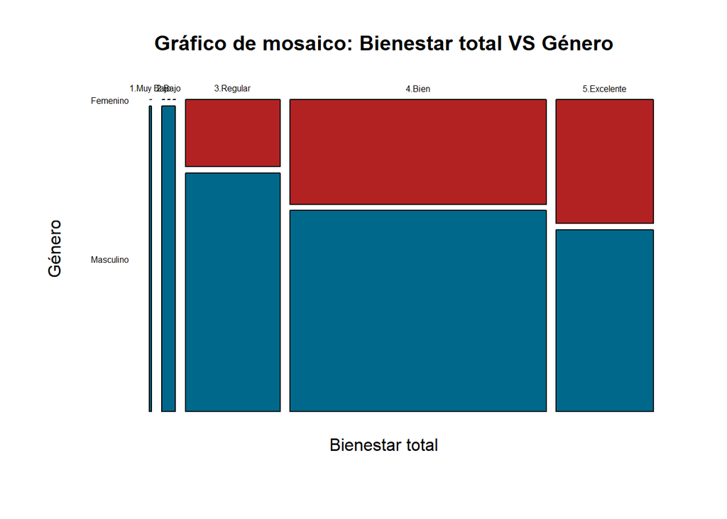

```r
mosaicplot(datosNuevos$rangoTotal~datosNuevos$Genero,col=c("firebrick","deepskyblue4"),
           main="Gráfico de mosaico: Bienestar total VS Género",
           xlab="Bienestar total",
           ylab="Género",
           cex.axis=0.5,
           las=1)
```

Como bienestar general, abarcamos al bienestar de salud, bienestar económico, lo ingresos, los recursos y si realizan actividades extracurriculares. Vemos que hay una mayor cantidad de varones en todos los rangos. Como tal, vemos que una mayor cantidad de alumnado UTEC se encuentra en un bienestar total Bien, debido a los distintos factores de notas medio y regulares, un IMC en el rango normal, entre otros.

Sin embargo, hay una menor cantidad con un bienestar muy bajo debido a los factores ya mencionado en los anteriores gráficos, por lo que en un análisis general el alumnado tiene un bienestar bien.

## Conclusiones y recomendaciones

#### Pregunta de investigación:

**¿Cuál es el nivel de bienestar personal de los alumnos de UTEC en épocas de pandemia (2020 a la actualidad)?**

El bienestar total (o personal) promedio de los estudiantes encuestados es de 69.47 y se estima que la media poblacional del bienestar personal esté en el rango de 68.59 y 70.35.

Sin embargo, considerando que el bienestar personal ideal es 95 puntos, el promedio de la muestra no está muy cercano a este valor, por lo que consideramos que el bienestar personal de los alumnos de UTEC es regular.

Y, a pesar que la media de los datos no está cercana a lo ideal, los datos en su mayoría están concentrados en el centro ya que el Q1=66.04 y Q3=73.76, lo que indica que el bienestar, en épocas de pandemia, no es ni tan buena ni tan mala

#### Objetivos de la investigación:

*- Identificar si el IMC promedio de los estudiantes de UTEC es óptimo.*

Hemos llegado a identificar el IMC promedio de los estudiantes de UTEC el cuál es 23.35, según la CDC menciona que el rango de IMC para una persona normal es de 18.5 a 25 por lo que sí se encuentra en este rango y es óptimo, lo que determina que los estudiantes de UTEC tienen un control moderado de su peso y talla.

*- Conocer el bienestar de salud y académico de los alumnos de UTEC en épocas de pandemia.*

*- Analizar las causas más comunes por las cuales los estudiantes presentan un bajo bienestar personal.*

En base al análisis de los demás bienestares, podemos ver que los alumnos tienen un bajo bienestar personal debido a sus bajas calificaciones, ya sea por no tener un lugr cómodo donde estudiar o por no salir de su zona de confort. Otra causa común es la mala alimentación que han estado llevando durante estos tiempos de pandemia, al no tener un control alimenticio no tendrá suficientes energías para estar concentrado en clases y eso puede empeorar su salud. También vemos que puede tener problemas emocionales o económicos que también son factores que se deben analizar a profundidad y ver que tan bajo es su bienestar de cierta persona y como se le puede ayudar.

*- Conocer las dificultades en su rendimiento académico.*

Las dificultades en su rendimiento académico de los estudiantes de UTEC se ha visto que son pocos los casos donde tienen cursos desaprobados y han jalado más de una ocasión algun curso a base de pruebas de hipótesis e intervalos de confianza, de tal manera que podamos ver que guardan cierta relación con la satisfacción de las clases, que tan cómodos pueden sentirse al llevar cursos de su carrera y su falta de compromiso con sus horas de estudio, no tienen disciplina o dedicación por estudiar.

*Recomendaciones*

- Se debería trabajar con una muestra más grande debido a que 200 alumnos en UTEC nos da una idealización de como ellos se encuentran en estos tiempos de Pandemia, se debería tomar entre el 50% y 60% del alumnado, de tal manera que se tengan resultados más apropiados.
- Nuestra muestra debe ser más aleatoria y con menos similitud en algunos datos para tener más conocimiento de la realidad de los alumnos de UTEC, sin embargo, esto ha ayudado a concluir algunos factores como relaciones entre el IMC, las notas y el bienestar.
- Para mayor eficacia en nuestro trabajo, se debería tomar más variables y factores que intervengan en el bienestar personal, además, podemos hablar de un bienestar laboral, mental y emocional, lo cual ayudaría a ser más precisos en saber como se siente cada alumno en estos tiempos de pandemia.

.